Ekstrakcja cech Michał Pastuszka, Karol Pysiak, Dominik Rafacz 14 - 05 - 2019

# 1 Problem

Dane, którymi będziemy się zajmowali, pochodzą z badań na temat emocji przeprowadzonych w Centrum Nauki Kopernik. Uczestnicy najpierw przystępowali do ankiety, która miała zbadać ich poglądy i intuicje na temat emocji, a następnie pokazywane im były zdjęcia twarzy aktorów, które mieli oceniać w skali smutek/złość-radość oraz stopień zaufania, jakim byliby skłonni obdarzyć osobę na zjęciu.

W dalszej części prezentamy przedstawiamy najciekawsze wyniki z eksploracji tychże danych.

# 2 Zbiór danych z ankiety

| Unikalny.identyfikator.Data.Czas | Wiek | Płeć | id_response | date | time | cechynieodzowne…zabawki.vs.książka.1 | cechynieodzowne…zabawki.vs.książka.2 | cechynieodzowne…zabawki.vs.książka.3 | cechynieodzowne…zabawki.vs.książka.4 | informacyjnosc…ssak.vs.Polak.1 | informacyjnosc…ssak.vs.Polak.2 | informacyjnosc…ssak.vs.Polak.3 | informacyjnosc…ssak.vs.Polak.4 | istota…Pies.vs.butelka.1 | istota…Pies.vs.butelka.2 | istota…Pies.vs.butelka.3 | istota…Pies.vs.butelka.4 | jednorodnosc…kamienie.szlachetne.vs.krzesła.1 | jednorodnosc…kamienie.szlachetne.vs.krzesła.2 | jednorodnosc..kamienie.szlachetne.vs.krzesła.3 | jednorodnosc..kamienie.szlachetne.vs.krzesła.4 | nieodwracalnosc…zwierzęta.vs.uczeń.1 | nieodwracalnosc…zwierzęta.vs.uczeń.2 | nieodwracalnosc…zwierzęta.vs.uczeń.3 | nieodwracalnosc…zwierzęta.vs.uczeń.4 | odrebnosc…drewno.vs.miękkie.1 | odrebnosc…drewno.vs.miękkie.2 | odrebnosc…drewno.vs.miękkie.3 | odrebnosc…drewno.vs.miękkie.4 | … |
| --- | --- | --- | --- | --- | --- | --- | --- | --- | --- | --- | --- | --- | --- | --- | --- | --- | --- | --- | --- | --- | --- | --- | --- | --- | --- | --- | --- | --- | --- | --- |
| 145037 | 23 | 1 | 41 | 110216 | 1899-12-31 09:40:21 | 8 | 2 | 8 | 1 | 9 | 9 | 6 | 8 | 10 | 10 | 10 | 10 | 6 | 8 | 10 | 7 | 2 | 8 | 2 | 4 | 9 | 10 | 1 | 5 | … |
| 145068 | 20 | 0 | 42 | 110216 | 1899-12-31 09:40:52 | 7 | 2 | 4 | 3 | 2 | 3 | 5 | 2 | 7 | 6 | 6 | 8 | 6 | 9 | 7 | 4 | 6 | 6 | 5 | 9 | 8 | 7 | 5 | 4 | … |
| 145302 | 38 | 1 | 67 | 110316 | 1899-12-31 09:43:06 | 10 | 2 | 9 | 8 | 5 | 2 | 5 | 5 | 5 | 5 | 5 | 5 | 8 | 10 | 10 | 10 | 5 | 10 | 10 | 0 | 8 | 10 | 10 | 10 | … |
| 146642 | 17 | 0 | 43 | 110216 | 1899-12-31 10:07:06 | 4 | 6 | 7 | 2 | 6 | 7 | 4 | 7 | 6 | 10 | 3 | 2 | 4 | 6 | 6 | 7 | 3 | 6 | 7 | 6 | 9 | 7 | 6 | 6 | … |
| 146657 | 17 | 0 | 45 | 110216 | 1899-12-31 10:07:21 | 3 | 10 | 3 | 1 | 7 | 6 | 2 | 8 | 10 | 10 | 10 | 0 | 7 | 3 | 6 | 1 | 6 | 10 | 2 | 6 | 8 | 8 | 4 | 1 | … |
| 146662 | 17 | 0 | 44 | 110216 | 1899-12-31 10:07:26 | 2 | 8 | 1 | 8 | 1 | 2 | 3 | 8 | 8 | 7 | 7 | 8 | 5 | 8 | 3 | 8 | 9 | 7 | 3 | 8 | 5 | 7 | 2 | 9 | … |

## 2.1 Korelacje

Ponieważ pytania w każdej grupie miały sprawdzić ogólny pogląd uczestnika na pewną własność emocji, możemy spodziewać się, że będą ze sobą skorelowane.

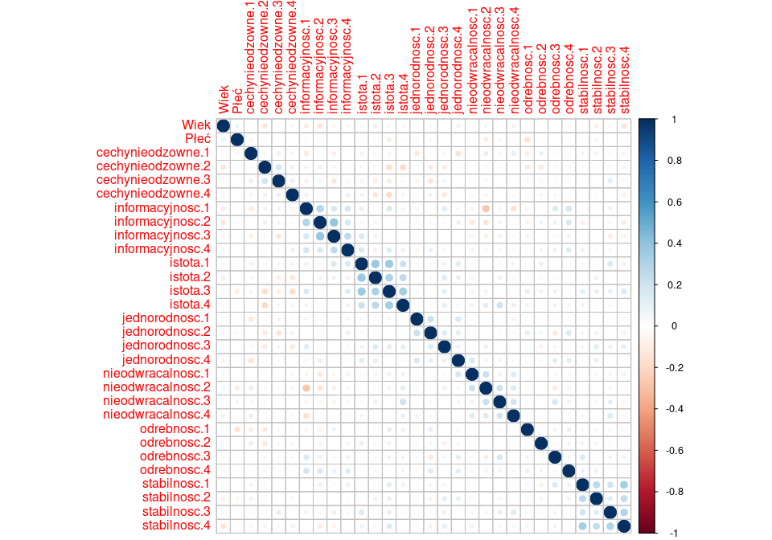

Pozytywną korelację można zauważyć szczególnie w grupach pytań o stabilność, istotę i informacyjność emocji, natomiast nie jest ona widoczna przy odrębności i cechach nieodzownych.

## 2.3 PCA

Ze względu na grupową charakterystykę pytań możemy podejrzewać, że zbiór będzie podatny na redukcję wymiarów.

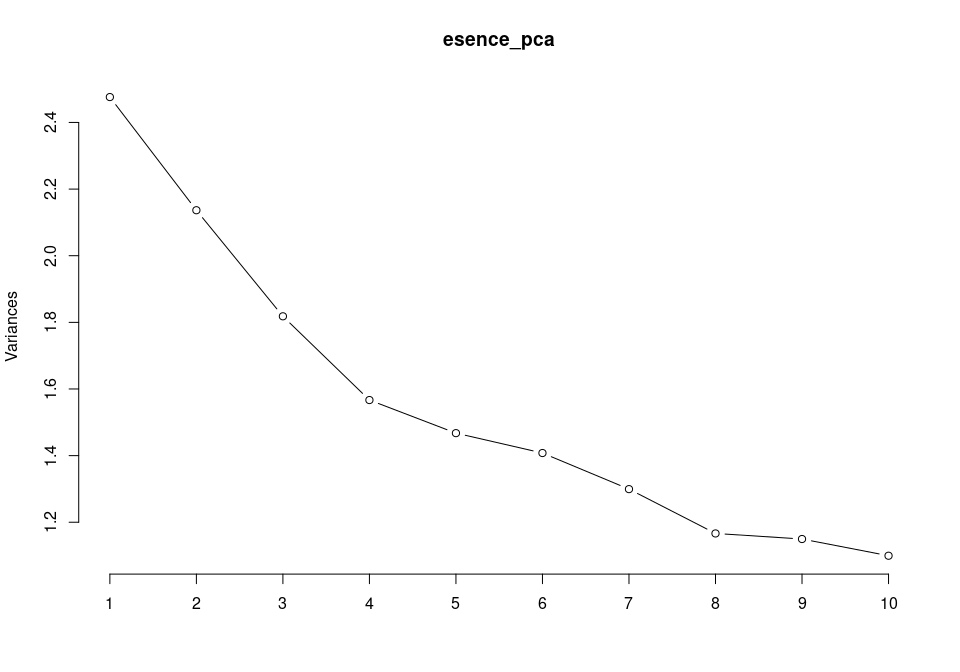

Jak widzimy z analizy PCA wynika, że zachowamy znaczną część informacji używając tylko czterech zmiennych. Co ciekawe jednak, nie wyróżnia się tu siedem, które było liczbą grup pytań.

## 2.4 t-SNE

Użyjemy teraz algorytmu t-SNE, aby spróbować wykryć widoczne klastry.

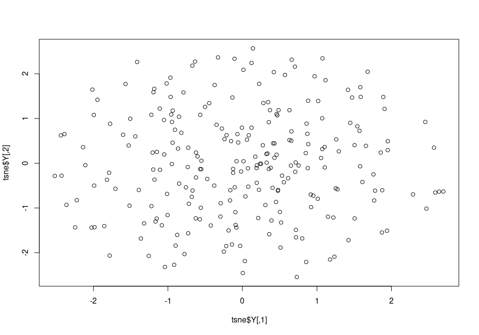

Niestety, w zbiorze nie widać wyraźnych grup.

# 3 Zbiór danych z eksperymentu

| ID | data | czas | plec | wiek | trial_within_EMOCJE | trail_within_ZAUFANIE | face_category_and_gender | NumerFoto | face_filename | response_EMOCJE | response_ZAUFANIE | response_latency_EMOCJE | response_latency_ZAUFANIE | FAC1_ISTOTA | FAC2_STABIL | FAC3_INFORM | correct_EMOCJE |
| --- | --- | --- | --- | --- | --- | --- | --- | --- | --- | --- | --- | --- | --- | --- | --- | --- | --- |
| 145037 | 110216 | 1899-12-31 09:40:21 | 1 | 23 | 19 | 20 | 15M | 15 | e15.jpg | 1 | 25 | 2722 | 3758 | 1.985804 | -1.544216 | 1.381097 | 0 |
| 145037 | 110216 | 1899-12-31 09:40:21 | 1 | 23 | 55 | 56 | 15M | 15 | p15.jpg | 0 | 40 | 2756 | 3326 | 1.985804 | -1.544216 | 1.381097 | 0 |
| 145037 | 110216 | 1899-12-31 09:40:21 | 1 | 23 | 75 | 76 | 15K | 15 | l15.jpg | 1 | 35 | 2569 | 3740 | 1.985804 | -1.544216 | 1.381097 | 0 |
| 145037 | 110216 | 1899-12-31 09:40:21 | 1 | 23 | 87 | 88 | 15M | 15 | i15.jpg | 0 | 40 | 1846 | 3977 | 1.985804 | -1.544216 | 1.381097 | 0 |
| 145037 | 110216 | 1899-12-31 09:40:21 | 1 | 23 | 99 | 100 | 15K | 15 | g15.jpg | 0 | 30 | 3154 | 4050 | 1.985804 | -1.544216 | 1.381097 | 0 |
| 145037 | 110216 | 1899-12-31 09:40:21 | 1 | 23 | 131 | 132 | 15K | 15 | d15.jpg | 2 | 35 | 2551 | 4594 | 1.985804 | -1.544216 | 1.381097 | 0 |

## 3.1 Brakujące wartości

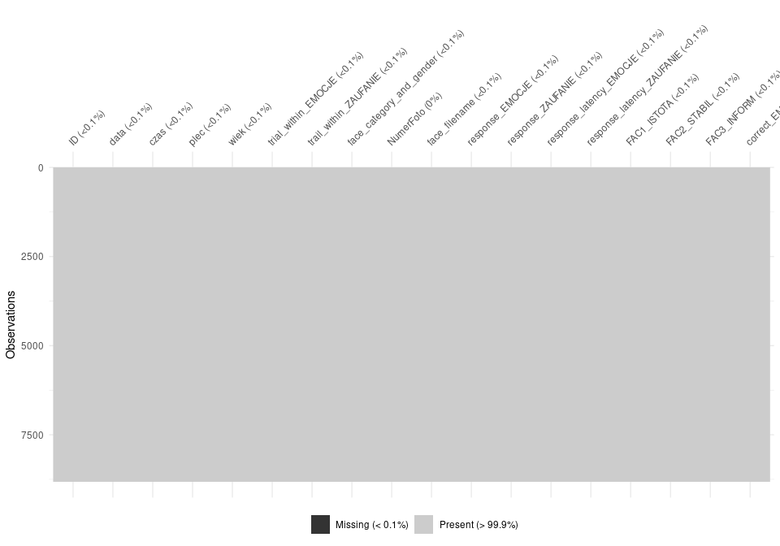

W zbiorze nie ma dużej liczby brakujących wartości, a jest ich dokładnie 16 i znajdują się w jakiejś jednej pogubionej linijce:

|  | ID | data | czas | plec | wiek | trial_within_EMOCJE | trail_within_ZAUFANIE | face_category_and_gender | NumerFoto | face_filename | response_EMOCJE | response_ZAUFANIE | response_latency_EMOCJE | response_latency_ZAUFANIE | FAC1_ISTOTA | FAC2_STABIL | FAC3_INFORM | correct_EMOCJE |
| --- | --- | --- | --- | --- | --- | --- | --- | --- | --- | --- | --- | --- | --- | --- | --- | --- | --- | --- |
| 4378 | NA | NA | NA | NA | NA | NA | NA | NA | 8 | NA | NA | NA | NA | NA | NA | NA | NA | 5 |

Ciekawostką jest, że podczas eksploracji przypadkiem trafiliśmy na dosć nietypowego ankietowanego:

| ID | data | czas | plec | wiek | trial_within_EMOCJE | trail_within_ZAUFANIE | face_category_and_gender | NumerFoto | face_filename | response_EMOCJE | response_ZAUFANIE | response_latency_EMOCJE | response_latency_ZAUFANIE | FAC1_ISTOTA | FAC2_STABIL | FAC3_INFORM | correct_EMOCJE |
| --- | --- | --- | --- | --- | --- | --- | --- | --- | --- | --- | --- | --- | --- | --- | --- | --- | --- |
| 165865 | 111316 | 1899-12-31 15:09:09 | 0 | 29 | 43 | 44 | 15K | 15 | l15.jpg | 5 | 50 | 1252 | 2554 | -0.5385061 | 0.0969726 | -0.1818411 | 0 |
| 165865 | 111316 | 1899-12-31 15:09:09 | 0 | 29 | 67 | 68 | 15M | 15 | e15.jpg | 5 | 50 | 967 | 818 | -0.5385061 | 0.0969726 | -0.1818411 | 0 |
| 165865 | 111316 | 1899-12-31 15:09:09 | 0 | 29 | 111 | 112 | 15K | 15 | d15.jpg | 5 | 50 | 766 | 825 | -0.5385061 | 0.0969726 | -0.1818411 | 0 |
| 165865 | 111316 | 1899-12-31 15:09:09 | 0 | 29 | 127 | 128 | 15M | 15 | p15.jpg | 5 | 50 | 772 | 783 | -0.5385061 | 0.0969726 | -0.1818411 | 0 |
| 165865 | 111316 | 1899-12-31 15:09:09 | 0 | 29 | 143 | 144 | 15M | 15 | r15.jpg | 5 | 50 | 931 | 847 | -0.5385061 | 0.0969726 | -0.1818411 | 0 |
| 165865 | 111316 | 1899-12-31 15:09:09 | 0 | 29 | 7 | 8 | 12K | 12 | c12.jpg | 5 | 50 | 1084 | 1809 | -0.5385061 | 0.0969726 | -0.1818411 | 2 |

## 3.2 Typy zmiennych

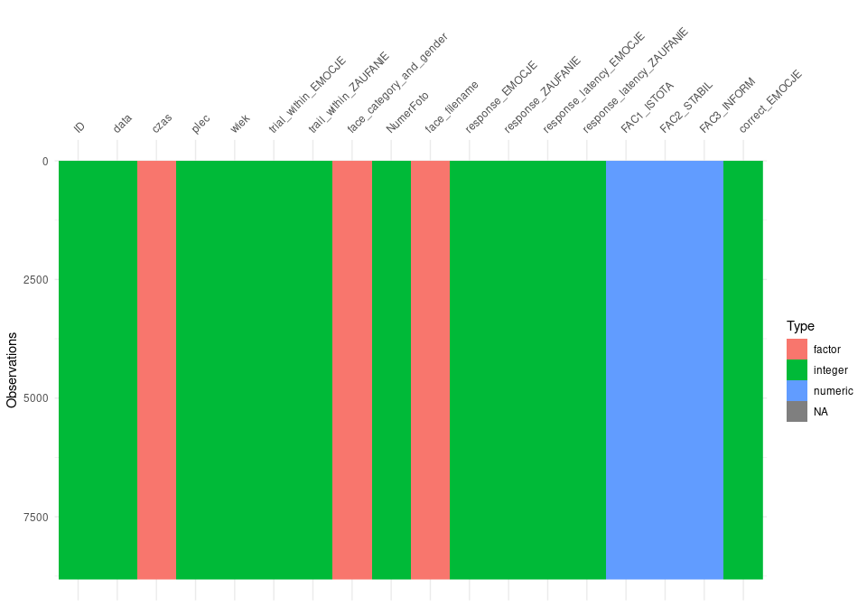

Większość zmiennych jest typu `Integer`. Bardzo nieprzyjaźnie wyglądają kolumny `data` i `czas`, ponieważ obie oznaczają dokładną datę badania, ale są rozdzielone, a `data` jest zapisana w bardzo nieczytelnej i trudnej do dalszego badania postaci. Postanowiliśmy połączyć te dwie kolumny w jedną kolumnę `data`, która przedstawia datę w jednym ze standardowych formatów.

## 3.3 Korelacja zmiennych

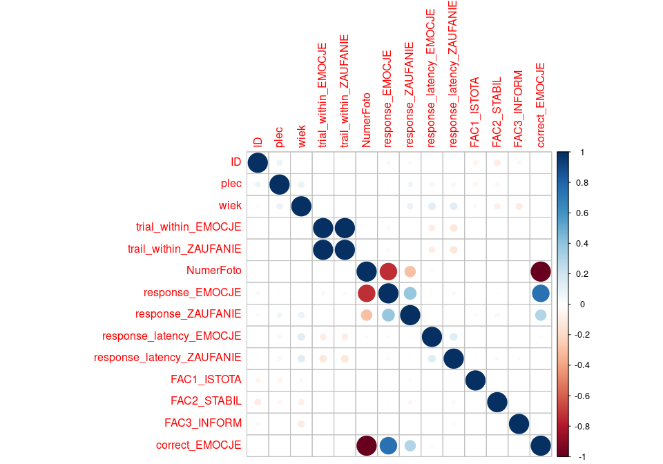

Zmienne `trail*` są ze sobą skorelowane, ponieważ jedna powstaje poprzez dodanie 1 do drugiej. `correct_EMOCJE` jest skorelowana z `NumerFoto`, ponieważ numery fotografi określały jaka emocja znajduje się na fotografii. `response_EMOCJE` jest skorelowana z `correct_EMOCJE`, ponieważ ankietowani dobrze zgadywali. Najciekawsza jest korelacja `response_EMOCJE` i `response_ZAUFANIE`, ponieważ ona oznacza, że zaufanie do osoby jest skorelowane z okazywanymi przez nią emocjami.

## 3.4 Rozkłady zmiennych

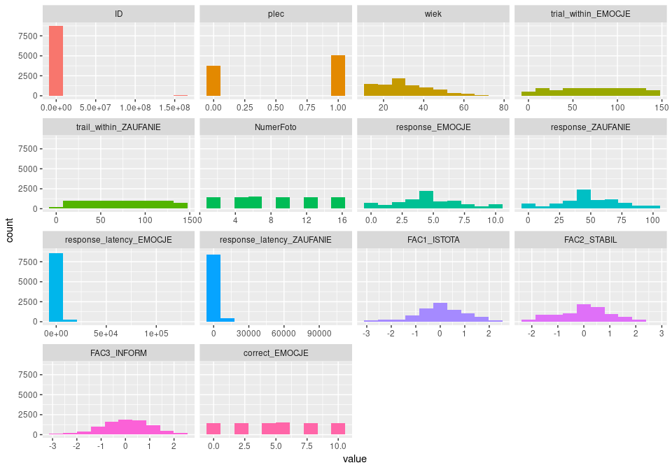

Większość zmiennych jest w miarę równo rozłożona, dzięki czemu unikniem może dużej ilości zakłóceń, które mogłyby się pojawić przy mocno skośnych zmiennych.

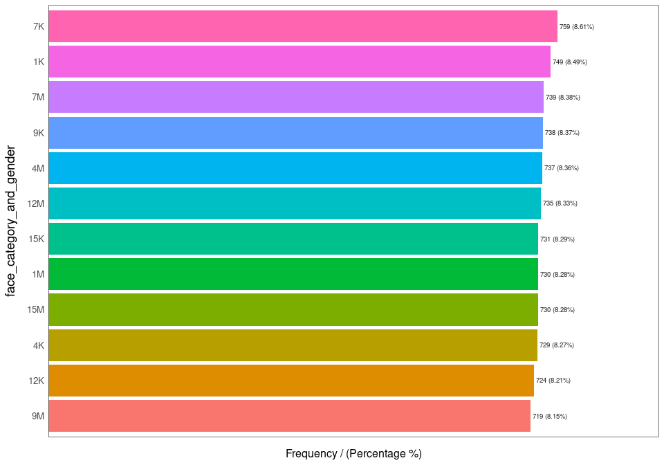

Jedyna zmienna kategoryczna warta przyjrzenia się to `face_category_and_gender`. Określa ona okazywaną emocję oraz płeć danej osoby. Jak widać osoby przygotowujące ten test zadbały o to, żeby w podawanych testach była zbliżona liczba zdjęć z każdej kategorii.

## 3.5 t-SNE

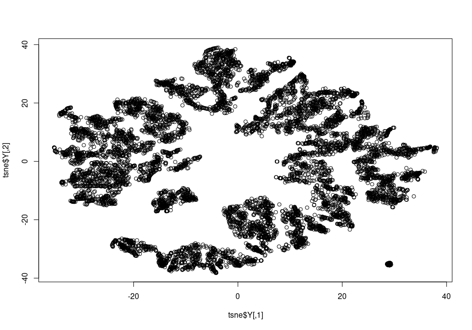

Nie ma jak narazie wyraźnych podziałów, ale zarysowują się delikatnie jakieś zależności.

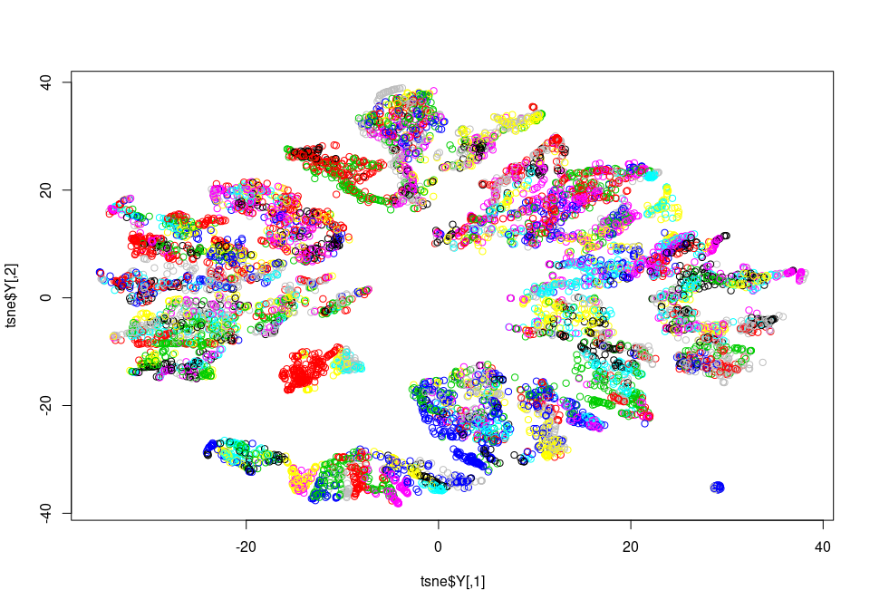

Wykres pokolorowany według zmiennej `wiek` wygląda jakby ta zmienna miała jakiś związek z przedstawionymi kształtami

## 3.6 Zależność między zmiennymi

### 3.6.1 Od płci

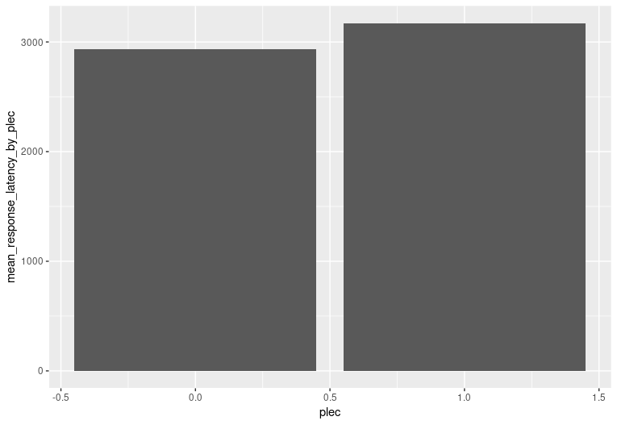

## 3.7 Oceny personalne

Postanowiliśmy sprawdzić, czy w danych można znaleźć odbicie hipotezy postawionej w badaniach:

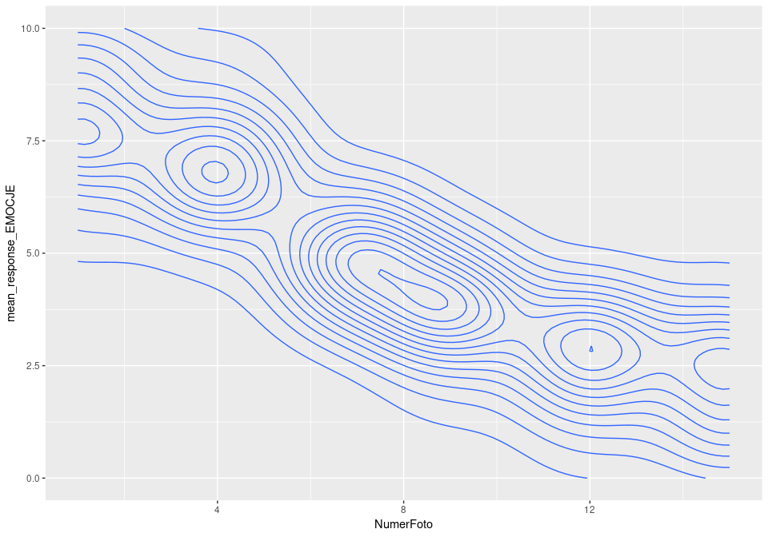

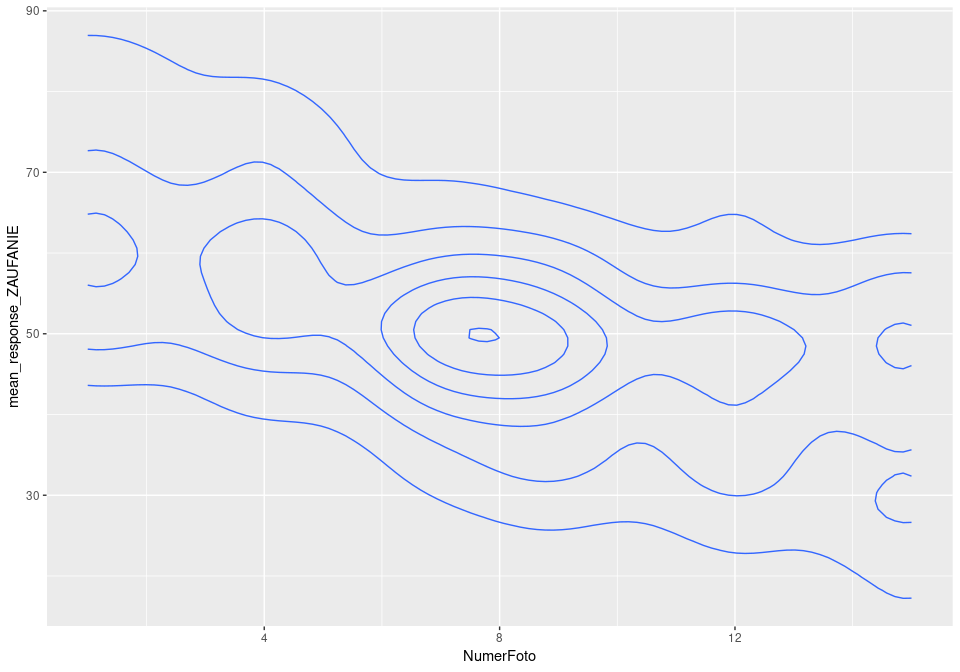

Reprezentacja osób z modelem “U” :

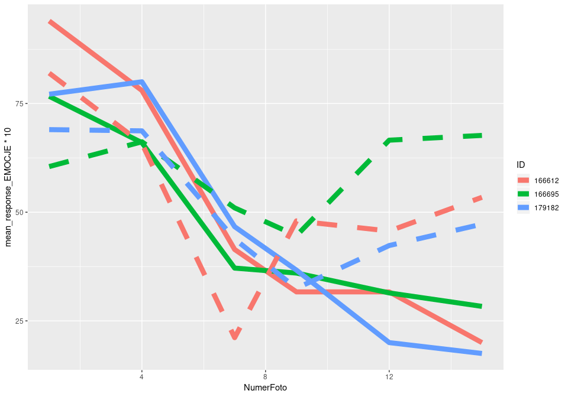

Reprezentacja osób z modelem “liniowym” :

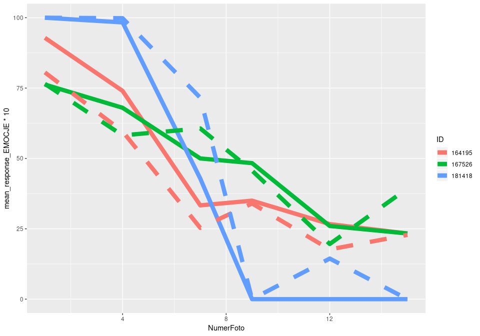

# 4 Połączone korelacje

Na końcu sprawdziliśmy jeszcze, jak kolumny z jednej ramki zależą od kolumn z ramki drugiej:

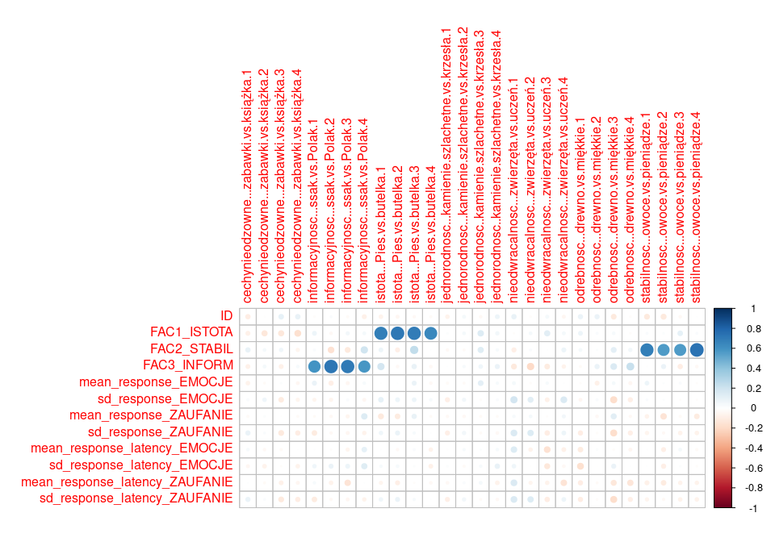